# Why map insect brains

2016-11-05T19:53:42+05:30

> “Most benevolent lecturer, whose topic is Insect Hearing: your effort’s truly fantastic but I’d much rather be dreaming” ~ 9 AM lecture, Laia Serratosa

### We all love maps

People’s interests vary but everyone loves a good map. Indeed, having a good map of something can be the difference between the known and the unknown. Claudius Ptolemy’s ~150 AD masterpiece Geographia changed how the world understood its globe (figure A). But not all maps are geographical. Sequencing the human genome in the 1990s/2000s revolutionised biology and medicine. An IKEA diagram allows you to construct as many Billy bookcases as you want at home. These maps do not completely solve problems, but they suggest solutions - so would it not be neat, if we had a map for one of the great under-charted (if now comparatively well-studied) frontiers of modern biology, the nervous system? But how detailed should our brain map be (figure B)? We already have low resolution atlases for many brains. But ideally, we would have a satellite map for the brain so that we could zoom in all the way to the point of communication between neurons, the synapse.

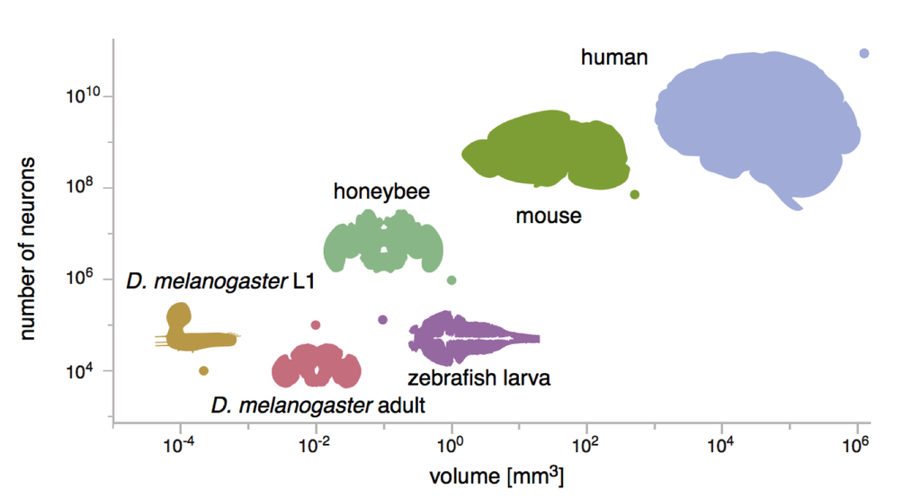

The problem is that current technology does not allow for such a map for an entire human brain’s ~86 billion cells (Herculano-Houzel 2009). The synapse-resolution image data storage alone would be in the zettabyte (10^21) range (Swanson and Lichtman 2016). Of older maps, there are essentially two varieties. Those that are smaller and perhaps foundational (figure A), and those that are wrong. Brain science has plenty of the latter. Think of the phrenology busts that appear so often in antique stores, and ascribe ‘hope’, ‘sublimity’ and ‘self-esteem’ to positions on the skull. But we are now making great progress with the small maps.

[figure not shown]

I have contributed to such maps for the vinegar fly, *Drosophila melanogaster*. Specifically, to a nub at the side of the brain known as the ‘lateral horn’, believed to inform innate responses to odour stimuli. As I will go on to explain, it is a good region to examine if one is interested in extracting circuit-to-behaviour hypotheses from a wiring diagram (figure B).

There is a direct connection between cartography and global trade, between the Human Genome Project and personalised medicine, and between some construction manual and the seat in which you are sat. Similarly, connectivity maps will provide a framework in which to think about brains more effectively, and help guide us to an understanding of how organisms do what they do, and maybe a bit about why.

[figure not shown]

Herculano-Houzel, Suzana. 2009. “The Human Brain in Numbers: A Linearly Scaled-up Primate Brain.” *Front. Hum. Neurosci.* 3 (November): 31.

Swanson, Larry W, and Jeff W Lichtman. 2016. “From Cajal to Connectome and Beyond.” *Annu. Rev. Neurosci.* 39 (July): 197–216.